# A First Guide to Programming in R

2022-01-23

# 1 How To Write and Run Scripts

Throughout this group, we’ll be using two different kinds of documents. To follow along with the examples, create a new script document in RStudio by using the keyboard shortcut Ctrl+Shift+N (Windows) or Command+Shift+N (Mac). Alternatively, clicking the green plus sign on the white sheet of the paper on the top left of the RStudio notebook will also allow you to create a new script file. From there, to learn code, I would encourage you to type the code snippets in the new script file rather than copy-pasting (I personally find typing things myself to be more useful – your mileage may vary).

To run code in R, you can highlight lines in your script document, then use the keyboard shortcut Ctrl+Enter (Windows) or Command+Enter (Mac). There’s also a “Run” button towards the top-left corner of the text window. Your code outputs should then appear in the Console window below, and any new variables you make will show up in the Environment window to the right.

# 2 The Basics

This is a short guide to learning how to code in `R`! If you are already familiar with coding, feel free to skip this section, as it will just cover the basics. Otherwise, read on!

## 2.1 Variables

A **variable** stores some kind of data within your program. A variable takes one of many types of data; in `R`, you don’t have to specify the type. The most relevant data types (most of which are applicable to other languages) are:

- `NULL/NA`: an undefined or “nothing” value.
- `bool`: a true or false value. `bool` stands for Boolean values. For example, `1 < 10` would yield a `TRUE` value, since 1 is less than 10. Note that in R, both `TRUE` and `T` mean “true”, and likewise `FALSE` and `F` mean “false”. The capitalization is important (you’ll get an error if you write `True` or `false`, for example)!
- `numeric` or `double`: some kind of number. Note that in `R`, `numeric` is a catch-all, while in other languages there is a clear distinction/incompatibility between`int`s (integer values, e.g. `3`) and `float`s (floating point/decimal values, e.g. `1.5`).
- `string`: a text value. These are defined using single OR double quotes, for example `'QBIO'` or `"quantitative biology"`. It’s a matter of preference; I mostly use double quotes out of habit (C++).
- `list`: some kind of ordered values. for example `[[1, 2.0, "three"]]`. As you can see, you can mix and match data types in `R` in a list.
- `data.frame` and `matrix`: essentially 2D lists or tables.
- `factors`: these are categorical variables in `R` (non-numerical variables in a sense). You’ll need to specify if a variable is a `factor` for some purposes, such as in plotting. In general, strings in your data will be factors, such as “old” or “young”, “rich” or “poor”, etc.

You can declare a variable in `R` in one of two equivalent ways (except in some edge cases you don’t really have to worry about). Note that the # denotes a comment in R, which is text that is written but not executed.

```r
var_string = "red" # one way to declare a variable, with an equals
var_num <- 3 # another way to declare a variable, with the arrow
var_vector = c(1, 2, 3) # a vector -- see more later
var_list = list(var_string, var_vector, 82)  # a list can have basically anything in it
```

### 2.1.1 A Note on Naming Variables

There is no convention on how to format your variable names, but the most important rule is to keep them just descriptive enough to describe the information contained. For example, these are examples of acceptable ways to name a variable (from best to fine):

```
    sum_of_ages = sum(ages)  # very clear, underscore are good
    sumOfAges = sum(ages)  # different formatting, but just as good
    AgeSum = sum(age)  # also good, though sometimes frowned upon to capitalize the first letter
    sum.age = sum(age)  # it's ok to use periods in a name in R, not good in other languages
```

Here’s some not-as-good ways:

```
    sum = sum(ages)  # avoid naming variables after functions, unclear what the sum is
    s = sum(ages)  # not descriptive, very unclear
    sumofages = sum(ages)  # hard to read
    SUMOFAGES = sum(ages)  # reserve caps for very important constants in your code
    blargh = sum(ages)  # funny but bad (some people code like this)
```

As you can see, there’s a million ways to name a variable. Don’t worry about it too much: keep things descriptive and concise, but I would err on the side of descriptive. Just be consistent and make sure things are readable.

**Exercise 2.1** In the following code box, create three new variables named ‘name’, ‘age’, and ‘birthday’ (in a MM/DD/YYYY format), containing your info. What data types are these? When you’re done, run the code to make sure you’ve declared your variables correctly.

```r
# code goes here!
```

## 2.2 Functions

**Functions**, on a very basic level, perform repeatable actions on the `parameters` passed to them. Functions have three important components:

- *Name*.
- *Parameters*. A function can have number of parameters (including 0), depending on how it’s defined.
- *Return value*. It’s return value is what it outputs. In `R`, you can return either no values or one value.

To call a function, use the syntax `funcname(arg1, arg2, etc.)`. You’ve seen functions before in math class, like $\sin(\pi)$ – the input is $\pi$, the name is $\sin$, and the output is whatever the $\sin$ value is (`0` in this case). You’ve also seen functions with multiple parameters before like addition, `x + y`: the function name is `+`, the two parameters are `x` and `y`, and the return value is whatever `x + y` is – you just substitute the values in. In `R`, you can add two numbers as follows (note that programming languages implement `+`; this is just a contrived example to show the syntax):

```r
x = 5
y = 7
sum(x, y)
```

```
## [1] 12
```

```r
x + y  # this is the same
```

```
## [1] 12
```

You can also save a function’s output (its return value) to a variable. For example, if I wanted save those numbers, I could do the following:

```r
z = sum(x, y)
z
```

```
## [1] 12
```

**Exercise 2.2** Use the `max` and `min` functions to find the largest value of `list_of_numbers` (see below), then store those two values in two different variables. Then find the product of the max and min, save it to another variable, and print it using the `print` function (note that both `max`, `min`, and `print` can all take in one parameter).

```r
list_of_numbers = c(1, 3, 4, 8, 1, 44, -3, 29, -12)
# min()
# max()
```

## 2.3 Writing Functions

Writing functions is extremely important, as it makes code more concise, easier to read, and more reusable. The way you write a function in `R` is as follows:

```
    function_name = function(arguments){
      code goes here

      return something
    }
```

To dissect the syntax: you define a function using the `function` keyword, and you put all keywords within the parentheses. Since functions often have more than one line, you use curly braces ({ }) to define its contents. Finally, at the end of the function, you *may* have a `return` statement, which is essentially its output. Again, not all functions have a `return` statement. For example, if I needed graph a bunch of different parabolas a lot of times, I could write the following function (remember that $y = ax^2 + bx + c$. Also, you don’t need to understand this code for now):

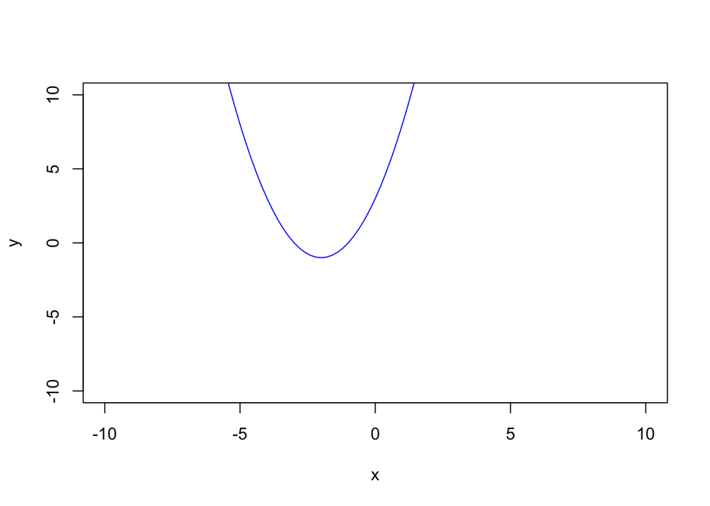

```r
graph_parabola = function(a, b, c){
  curve(a*x^2 + b*x + c, xlim = c(-10, 10), ylim = c(-10, 10),
        col = "blue", ylab = "y")
  # there is no return statement -- the output is in the plot window!
}

graph_parabola(1, 4, 3) # much easier than typing the above code!
```

The main takeaway is that you can simply call the function `graph_parabola(a, b, c)`instead of specifying a bunch of parameters in plot. In general, you should write a function whenever you call the same functions with the same parameters on different inputs. From anecdotal evidence, people tend to underuse functions while performing data analysis and just end up copy and pasting code. Your analysis will be a lot clearer to other people and to future you if you use them more often!

**Exercise 2.3** Write a function called `quad_form` that accepts three parameters (`a, b, c`) and return the positive solution of the quadratic formula (so return $x = \frac{-b + \sqrt{b^2 - 4ac}}{2a}$). A few hints:

```r
quad_form = function(a, b, c){

}
```

## 2.4 Logic and Control Flow

Now that we know how to store data and manipulate it with functions, how do you decide when to call functions? **Control flow** allows you to determine which chunk of code to run under which situations.

Logical statements evaluate either to `TRUE` or `FALSE` (they are `bool`s). In general, you will use comparison operators Here are a list of the most commonly-used ones:

| Operator | Explanation |
| --- | --- |
| `==` | Equals to (e.g. `"red" == "red"` is `TRUE`; `"1" == "2"` is `FALSE`) |
| `!=` | Not equals to |
| `<` | Less than |
| `>` | Greater than |
| `<=` | Less than or equal to |
| `>=` | Greater than or equal to |
| `%in%` | Present in a vector/list (e.g. `2 %in% [[1, 2, 3]]` is `TRUE`) |

All of these except the last (`%in%`) are universal to most other programming languages, so be sure to understand them!

You can also perform more operators on these `bool` comparisons. There are three main operations: `and`, `or`, and `not`:

| Operator | Explanation |
| --- | --- |
| `&` | (And) `TRUE` if both left and right are `TRUE` |
| `\|` | (Or) `TRUE` if either left or right are `TRUE` |
| `!` | (Not) flips `TRUE` to `FALSE`, and vice versa. |

(note: in R, if you use `&&` and `||` on a vector, you will only evaluate the first value, rather than getting an entire vector. If you want a vectorized logical operator, use `&` and `|` — see the section on vectors for more information. In general, you’ll want to use the single character version of these operators. in R.)

The `if` keyword is the main control flow keyword that you will use. If the statement within the `if` code block (i.e. the part within the curly braces) is `TRUE`, then it will run.

The `else` and `else if` keywords go with the `if` keyword. They are somewhat self-explanatory: if the `if` statement is `TRUE`, do what is in the `if` block; otherwise, do what is in the `else` block. The `else if` keyword is related to the `else` keyword, in that it will happen if the `if` statement is false AND the `else if` statement is true. Can you predict the output of the following code block? Then, to check your answer, copy and paste the code into your document and run it!

```r
if (1 > 2){
  print("The if statement is true.")
} else if(2 > 1){
  print("The else if statement is true.")
} else{
  print("Neither the if NOR the else if is true.")
}
```

As you can see, these statements are evaluated in order: first, check the `if`. Since that was `FALSE`, we move onto the next statement. We check the `else if` statement, which is `TRUE`. Therefore, we don’t check the `else` block. The important thing to note is that when you have an if/else if/else block, *only one* of the blocks can execute. Another thing to keep in mind is that you can have any number of `else if` statements (including 0), and you can have either 0 or 1 `else` blocks. All of the following constructions are valid:

- if
- if/else
- if/else if
- if/else if/else if (etc.)
- if/else if/else if (etc.)/else

Note that if you want to use `else if` or `else`, you MUST have one corresponding `if` statement.

**Exercise 2.4** Predict the output of this program! To check your answer, just copy the code and run it.

```r
print("Green eggs and ham.")

if(1 > 2 || "red" == "blue"){
  print("I do not like green eggs and ham.")
}

if("red" == "green" || 2 > 1){
  print("I do not like them, Sam-I-Am.")
}

if(!(3 != 3 || "pass" == "fail")){
  print("I do so like green eggs and ham.")
}
```

## 2.5 Loops

Sometimes, we want to do something many times, or we want to do the same operations on a large number of things. To avoid writing out very repetitive blocks of code, we use loops to repeat doing an action many times. We have two main ways to loop: `for` and `while` loops.

**A VERY IMPORTANT NOTE**: in `R`, you want to avoid using loops. We’ll discuss ways to get around them in the last section. This section therefore is just to introduce basic programming fundamentals. On the other hand, if you can’t think of a way to do something without using a loop, just use a loop – don’t waste time by trying to find a more elegant solution if it isn’t absolutely necessary (look up premature optimization).

### 2.5.1 While Loops

`while` loops look a lot like `if` statements. Instead of just executing something once, `while` loops will continue executing the code block until the condition is `FALSE`. Compare the two following blocks of code. In the first, you multiply once; in the second, you multiply until the condition in the `while` loop is `FALSE`.

```r
i = 1
if(i < 256){
  i = i*2
  print(i)  # only happens once
}
```

```
## [1] 2
```

```r
i = 1
while(i < 256){
  i = i * 2
  print(i)  # this happens until i = 256
}
```

```
## [1] 2
## [1] 4
## [1] 8
## [1] 16
## [1] 32
## [1] 64
## [1] 128
## [1] 256
```

**Exercise 2.5** Add random numbers to `x` until `x` is greater than 5, printing `x` after every addition. Use the function `runif(1)` to generate one random number at a time.

```r
x = 0
# code goes here
```

### 2.5.2 For Loops

`for` loops do something *for* each element in some list (in `R` and Python, at least). So, it does something to the first element, the second, and so on.

As a example, the following code block multiplies each integer between 1 and 10 (generated by `1:10`) by 10. In more detail, `i` takes on the value `1`, and `1*10` is printed (i.e. outputted to the console), then `i` takes on the value `2`, and `2*10` is printed, until the last value is reached. By convention, you use `i` as the “dummy” counting variable (standing for index). If you have nested `for` loops (i.e. a loop inside your loop), you’ll commonly see `j` in the second level and `k` in the third, etc.

```r
for (i in 1:10){
  print(i*10)
}
```

```
## [1] 10
## [1] 20
## [1] 30
## [1] 40
## [1] 50
## [1] 60
## [1] 70
## [1] 80
## [1] 90
## [1] 100
```

`for` loops are the standard technique for doing something a set number of times.

**Exercise 2.6** What happens when you run the following code? Notice that the for loop works, even though you don’t use `i` at all in the loop.

```r
for (i in 1:5){
  print("USC")
}
```

However, just to reiterate, **avoid looping in R**. If you absolutely need to, in a lot of cases it’s better to just got through everything in a vector with a `for` loop.

**Exercise 2.7** Print out 10, 9, 8, …, 1 in descending order. Can you think of more than one way to do it? (There’s a very simple way to do so without looping.)

```r
# code goes here
```

**Exercise 2.8** (nested for loops) Print out all the possible sums from rolling two dice, with repetition (i.e. 1+1, 1+2, etc.). You should see 36 values. In this case, it’s hard to avoid using `for` loops, although you can cut it down to just 1.

```r
# code goes here
```

### 2.5.3 Ways to Avoid Looping

**Exercise 2.9** Given the following $10 \times 10$ matrix, calculate the mean across each row and down each column. Store these store values two separate numeric vectors without using a for loop. (Hint: one of the previously-mentioned functions is useful).

```r
mean_mat = matrix(1:100, nrow = 10, ncol = 10)  # data frame of values

## code goes here
```

## 2.6 Further Basic Practice

These concepts should be enough to get you through the first few activities, but if you want more practice check out the `swirl` package! It has a bunch of activities to help you learn. Also, look online – there’s a million tutorials floating around. Finally, the best way to practice (in my opinion) is just to get your hands dirty with actually doing some analysis.

# 3 R-Specific Syntax

`R` as a programming language is kind of weird, in that there’s a lot of syntax specific to the language to learn. Here’s an overview of the most important concepts.

## 3.1 Getting Help

If you ever wonder what a package or a function does, type `?` before its name (or equivalently, call the `help()` function). For example, let’s say I’m not sure what the function `ifelse()` does. Let’s take a look!

```r
?ifelse
# same effect: help(ifelse)
```

If you run that line of code, you should see help topics on `ifelse()` pop up in the help window! It turns out the `ifelse()` function is a vectorized logical operator (more on that later). `R` documentation tends to be very comprehensive, so always use the question mark!

Another helpful command is `args()`, which tells you the arguments a function takes if you ever forget. For example, let’s say I wanted to see what order I need to put my parameters for `ifelse`. Just do the following:

```r
args(ifelse)
```

```
## function (test, yes, no)
## NULL
```

This tells you very quickly that you need to put your logical operator first, then its output is it’s `TRUE`, then if its `FALSE`. You can get the same information by using the `?`, but this method is faster if you just want to check the arguments.

Finally, if you run into any errors, you have any further questions, or if you’re not sure how to do something, **Google is your friend!** Being able to read documentation and search for help online are very important skills in coding jobs (we encourage searching online, as opposed to academic classes, which are really focused on testing your low-level understanding).

## 3.2 Setting Up the Working Environment

When you first open a document, you want to make sure that your working directory is set properly. That is, when you start reading files into your programs and writing outputs, you want to know which file you’re currently in.

- To figure out where you are, simply type `getwd()` into the console (this is equivalent to `pwd` in Unix).
- To set your directory, type `setwd("DIRECTORY")` (this is equivalent to `cd`, except you need to put quotes around the directory in question).
- If you want to see the files in the current directory, type `list.files()` (this is equivalent to `ls`).

For example, say we have the following directory structure:

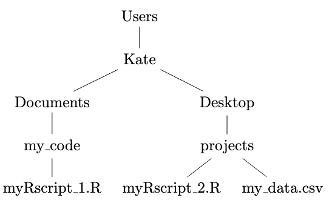

To run `myRscript_2.R`, run `setwd("../Desktop/projects/")` (again, compare to `cd ../Desktop/projects`). The reason you want `setwd()` is in case your program writes any files, and it makes it easier to read files in.

## 3.3 Installing Packages

A “package” (also known as a “library”) contains functions, and sometimes data sets, which are not implemented in the base installation of R. Packages are really nice because writing functions is error prone and time consuming, and often these packages have an optimized implementation (i.e. they run faster). Luckily, installing and using packages is very simple.

```r
if(!require(tidyverse)){
  install.packages("tidyverse")
}

library(tidyverse)
```

The `if` statement just checks if you need to install the package, and `library()` loads it into your session of `R`. You only need to install a package once, BUT you must load it into your `R` environment every time using `library()` after you restart R.

*Remark*. If you don’t like this syntax, install and load the `pacman` package and just use the `p_load()` function to install and load functions in one go (you’ll see me use this in scripts because I’m lazy):

```r
library(pacman)  # you need to do this first

# this installs the package for you if you don't have it already
# and loads it into your workspace with library
p_load(tidyverse)
```

*Remark*. Sometimes, you only need one function from a package, and it’s generally undesirable to load an entire package in just for that one package. In that case, you’ll often see people use the double colon syntax to access a specific function from a package in the form of `PACKAGENAME::PACKAGEFUNCTION`. For example:

```r
# we don't need run library(pacman)
pacman::p_load(tidyverse)
```

This syntax also comes in handy for when two packages write two functions with the same name, and it allows you to select which function you want to call. This doesn’t happen very often, but it’s good to know when it does.

## 3.4 Dataframes

Data frames are two-dimensional representations of data, often with rownames and column names. Let’s look at the `mtcars` data frame to start with, which is a data set that comes with R. There’s three main ways to examine data tables:

- `head()` – this will show the first 6 rows.
- `str()` – this will show everything and the data type.
- `glimpse()` – this function is implemented in the `tidyverse` package. It works similarly to `str()`, but it’s somewhat more informative about the data type. (For example, `str()` will show `num`, indicating they are numbers. When you run `glimpse()` on the `mtcars` data set, you’ll see `<dbl>`, which indicates that the numbers are represented non-integer values).

**Exercise 3.1** Use these three commands to look at `mtcars`! Match the outputs to the ones you see below. Be sure to load in `tidyverse` using `library()`!

```
## [1] "(1)"
```

```
## 'data.frame':    32 obs. of  11 variables:
##  $ mpg : num  21 21 22.8 21.4 18.7 18.1 14.3 24.4 22.8 19.2 ...
##  $ cyl : num  6 6 4 6 8 6 8 4 4 6 ...
##  $ disp: num  160 160 108 258 360 ...
##  $ hp  : num  110 110 93 110 175 105 245 62 95 123 ...
##  $ drat: num  3.9 3.9 3.85 3.08 3.15 2.76 3.21 3.69 3.92 3.92 ...
##  $ wt  : num  2.62 2.88 2.32 3.21 3.44 ...
##  $ qsec: num  16.5 17 18.6 19.4 17 ...
##  $ vs  : num  0 0 1 1 0 1 0 1 1 1 ...
##  $ am  : num  1 1 1 0 0 0 0 0 0 0 ...
##  $ gear: num  4 4 4 3 3 3 3 4 4 4 ...
##  $ carb: num  4 4 1 1 2 1 4 2 2 4 ...
```

```
## [1] "(2)"
```

```
##                    mpg cyl disp  hp drat    wt  qsec vs am gear carb
## Mazda RX4         21.0   6  160 110 3.90 2.620 16.46  0  1    4    4
## Mazda RX4 Wag     21.0   6  160 110 3.90 2.875 17.02  0  1    4    4
## Datsun 710        22.8   4  108  93 3.85 2.320 18.61  1  1    4    1
## Hornet 4 Drive    21.4   6  258 110 3.08 3.215 19.44  1  0    3    1
## Hornet Sportabout 18.7   8  360 175 3.15 3.440 17.02  0  0    3    2
## Valiant           18.1   6  225 105 2.76 3.460 20.22  1  0    3    1
```

```
## [1] "(3)"
```

```
## Rows: 32
## Columns: 11
## $ mpg  <dbl> 21.0, 21.0, 22.8, 21.4, 18.7, 18.1, 14.3, 24.4, 22.8, 19.2, 17.8,…
## $ cyl  <dbl> 6, 6, 4, 6, 8, 6, 8, 4, 4, 6, 6, 8, 8, 8, 8, 8, 8, 4, 4, 4, 4, 8,…
## $ disp <dbl> 160.0, 160.0, 108.0, 258.0, 360.0, 225.0, 360.0, 146.7, 140.8, 16…
## $ hp   <dbl> 110, 110, 93, 110, 175, 105, 245, 62, 95, 123, 123, 180, 180, 180…
## $ drat <dbl> 3.90, 3.90, 3.85, 3.08, 3.15, 2.76, 3.21, 3.69, 3.92, 3.92, 3.92,…
## $ wt   <dbl> 2.620, 2.875, 2.320, 3.215, 3.440, 3.460, 3.570, 3.190, 3.150, 3.…
## $ qsec <dbl> 16.46, 17.02, 18.61, 19.44, 17.02, 20.22, 15.84, 20.00, 22.90, 18…
## $ vs   <dbl> 0, 0, 1, 1, 0, 1, 0, 1, 1, 1, 1, 0, 0, 0, 0, 0, 0, 1, 1, 1, 1, 0,…
## $ am   <dbl> 1, 1, 1, 0, 0, 0, 0, 0, 0, 0, 0, 0, 0, 0, 0, 0, 0, 1, 1, 1, 0, 0,…
## $ gear <dbl> 4, 4, 4, 3, 3, 3, 3, 4, 4, 4, 4, 3, 3, 3, 3, 3, 3, 4, 4, 4, 3, 3,…
## $ carb <dbl> 4, 4, 1, 1, 2, 1, 4, 2, 2, 4, 4, 3, 3, 3, 4, 4, 4, 1, 2, 1, 1, 2,…
```

To access a column by *name*, you would use the `$` operator. If you look back on the `str()` output, you’ll see these dollars signs – these means that they are column elements!

`R` accesses values by `[row, column]` order. Note that the square bracket syntax is fairly standard across programming languages to access elements in a list or table. If you leave an element in a bracket empty, it means to select everything (this is most common when you want to select a row or column from a data frame or matrix).

**Note that `R` is 1-indexed**, unlike most languages you are probably familiar with (the “index” is the numeric location of the value). This is to say, the top left element is located at (1, 1) and NOT (0, 0).

Therefore, if you want to access by *index* (the number in which they appear), use the square bracket (`[ ]`) syntax. So, based on the 1 indexing, `dataframe[, 1]` is the first column, `dataframe[3, ]` is the third row, etc.

```r
# dollar sign version
mtcars$mpg
```

```
##  [1] 21.0 21.0 22.8 21.4 18.7 18.1 14.3 24.4 22.8 19.2 17.8 16.4 17.3 15.2 10.4
## [16] 10.4 14.7 32.4 30.4 33.9 21.5 15.5 15.2 13.3 19.2 27.3 26.0 30.4 15.8 19.7
## [31] 15.0 21.4
```

```r
# square bracket version
# since the rows was left empty, it will select all rows
# note that this gets the first column, which is mpg
mtcars[, 1]
```

```
##  [1] 21.0 21.0 22.8 21.4 18.7 18.1 14.3 24.4 22.8 19.2 17.8 16.4 17.3 15.2 10.4
## [16] 10.4 14.7 32.4 30.4 33.9 21.5 15.5 15.2 13.3 19.2 27.3 26.0 30.4 15.8 19.7
## [31] 15.0 21.4
```

```r
# this is the third row
# there is no equivalent "$" way to get rows by name
mtcars[3, ]
```

|  | mpg | cyl | disp | hp | drat | wt | qsec | vs | am | gear | carb |
| --- | --- | --- | --- | --- | --- | --- | --- | --- | --- | --- | --- |
| Datsun 710 | 22.8 | 4 | 108 | 93 | 3.85 | 2.32 | 18.61 | 1 | 1 | 4 | 1 |

**Exercise 3.2** Create a new variable `mtcars_4`, and assign to it fourth column from the `mtcars` data set. Do it using the `$` syntax and the square bracket index! (You may need use one of the `names()`, `head()`, `str()`, or `glimpse()` functions to identify the name of the fourth column).

```r
# code goes here
```

```r
# code goes here
```

```r
head(mtcars)
```

|  | mpg | cyl | disp | hp | drat | wt | qsec | vs | am | gear | carb |
| --- | --- | --- | --- | --- | --- | --- | --- | --- | --- | --- | --- |
| Mazda RX4 | 21.0 | 6 | 160 | 110 | 3.90 | 2.620 | 16.46 | 0 | 1 | 4 | 4 |
| Mazda RX4 Wag | 21.0 | 6 | 160 | 110 | 3.90 | 2.875 | 17.02 | 0 | 1 | 4 | 4 |
| Datsun 710 | 22.8 | 4 | 108 | 93 | 3.85 | 2.320 | 18.61 | 1 | 1 | 4 | 1 |
| Hornet 4 Drive | 21.4 | 6 | 258 | 110 | 3.08 | 3.215 | 19.44 | 1 | 0 | 3 | 1 |
| Hornet Sportabout | 18.7 | 8 | 360 | 175 | 3.15 | 3.440 | 17.02 | 0 | 0 | 3 | 2 |
| Valiant | 18.1 | 6 | 225 | 105 | 2.76 | 3.460 | 20.22 | 1 | 0 | 3 | 1 |

```r
# code goes here
```

`R` also allows you to select multiple rows and/or columns. You can generate a range of integers using a colon (`:`), which returns a integer vector. These numbers will then be the rows/columns you select:

```r
mtcars[, 1:3]  # equivalent to mtcars[, c(1,2,3)], the first 3 columns
```

|  | mpg | cyl | disp |
| --- | --- | --- | --- |
| Mazda RX4 | 21.0 | 6 | 160.0 |
| Mazda RX4 Wag | 21.0 | 6 | 160.0 |
| Datsun 710 | 22.8 | 4 | 108.0 |
| Hornet 4 Drive | 21.4 | 6 | 258.0 |
| Hornet Sportabout | 18.7 | 8 | 360.0 |
| Valiant | 18.1 | 6 | 225.0 |
| Duster 360 | 14.3 | 8 | 360.0 |
| Merc 240D | 24.4 | 4 | 146.7 |
| Merc 230 | 22.8 | 4 | 140.8 |
| Merc 280 | 19.2 | 6 | 167.6 |

[output cut: 22 more lines]

```r
mtcars[1:3, ] # gets the first three rows, since the columns are unspecified
```

|  | mpg | cyl | disp | hp | drat | wt | qsec | vs | am | gear | carb |
| --- | --- | --- | --- | --- | --- | --- | --- | --- | --- | --- | --- |
| Mazda RX4 | 21.0 | 6 | 160 | 110 | 3.90 | 2.620 | 16.46 | 0 | 1 | 4 | 4 |
| Mazda RX4 Wag | 21.0 | 6 | 160 | 110 | 3.90 | 2.875 | 17.02 | 0 | 1 | 4 | 4 |
| Datsun 710 | 22.8 | 4 | 108 | 93 | 3.85 | 2.320 | 18.61 | 1 | 1 | 4 | 1 |

```r
mtcars[c(2, 6), 4]  # gets the 4th element of rows 2 and 6
```

```
## [1] 110 105
```

```r
mtcars[10:12, c(2, 4, 5)]  # gets the elements in the 2nd, 4th, and 5th columns of rows 10, 11, 12
```

|  | cyl | hp | drat |
| --- | --- | --- | --- |
| Merc 280 | 6 | 123 | 3.92 |
| Merc 280C | 6 | 123 | 3.92 |
| Merc 450SE | 8 | 180 | 3.07 |

**Exercise 3.4** Now, do the following to practice accessing data in data frames.

1. Get the first three columns of `mtcars`.
2. Get the first two rows of the last four columns of `mtcars`. (Hint: use the `dim()` command to see how many columns are in `mtcars`.)
3. Get the even-numbered rows and from `mtcars`. (Hint 1: you can create a new variable that contain even numbers only, and put that variable as the rows.) (Hint 2: The variable is equal to `1:16 * 2`).

```r
# code goes here
```

Other useful methods to call on a data table are `rownames()` and `colnames()`, which gives you the row names and column names, respectively. There are many more, but I can’t type them all out unfortunately. You’ll have to Google how to perform a specific function to see if there’s a built-in function!

## 3.5 Reading and Writing Files

Often, you want to read in data from a spreadsheet file and to write tables to new files (most programming languages can do this). To read tables, use the `read.table()` function. To write a data frame, use `write.table()`. If you want more information about them, type `?read.table` and/or `args(read.table)` into the `R` console! (This advice applies to all `R` functions). The most important arguments for `read.table()` are:

- `file`. This is the path to the file you want to read in, and will typically be the first argument. This is a string, so don’t forget your quotes!
- `header`: you want to tell `R` if the first row is a header row with column names or not. If the data you read in looks wonky in R, it’s probably because you need to change this setting. This is a boolean, where `TRUE` means that the first row is a header, and `FALSE` otherwise.
- `sep`: this tells `R` what separates columns. For example, in a `csv` (comma-separated values), you want to type `read.table(file.csv, sep=",")`, while for a `tsv` (tab-separated values), you should use `read.table(file.csv, sep="\t")`. Note that `sep` defaults to `"\t"`, and there is a `read.csv()` function that is identical to `read.table()`, but defaults the `sep` parameter to `","`.

Likewise, the argument to `write.table()` (and equivalently, `write.csv()`) are:

- `x`. This is the object (data frame) you want to write out. It’s called `x` in the documentation, and will typically be the first argument.
- `file`. Again, this is the path and file name you want to write to. Note that this parameter is a string, and remember that you will need to specify the file extension! (So for example, write `file="spreadsheet.csv"`, not `file="spreadsheet"`).

```r
cereal = read.csv("cereal.csv")
write.csv(cereal, "cereal.csv") # nothing actually gets changed
```

**Exercise 3.5** We have included the `cereal.csv` data set, which contains nutritional information about a set of cereals. For information about what the columns represent, see [here](https://www.kaggle.com/crawford/80-cereals/version/2). We’ll be using it for the rest of the notebook!

1. Read in the cereal data into an object named `cereal` (refer to the previous line of code). Refer to the `getwd()` and `setwd()` functions mentioned previously if you get an error relating to not being able to find the file.
2. Get a summary of the data using the function of your choice.
3. Create a new variable, `cereal_names`, which contains the names of the cereals.
4. Look through `cereal_names` and identify your three favorite cereals (or just pick any three that aren’t too close together). Create a new vector, `favorite_cereals`, which contains your three favorite cereals. (Use the `c("cereal 1", "cereal 2", "cereal 3")` syntax to make this variable, replacing cereal 1/2/3 with the names of your favorites).

```r
# code goes here
```

*Remark*. If you’d rather not muck around with the parameters for reading/writing files, install and load the package `data.table`, and use the functions `fread()` (fast read) and `fwrite()` (fast write), which automatically detects the separator and just runs faster (we will use this package in a few weeks to read in data, since it’s just so much faster). You probably also want to put the line `options(datatable.fread.datatable=FALSE)` right after you load the package, which universally sets the `data.table` parameter to `FALSE`, as `data.table`s work differently from a `data.frame`. Otherwise, you’ll probably get confused when you try to use the data frame syntax.

# 4 Vectors, Vectorized Operators, and Boolean Indexing

## 4.1 Vectors and Vectorized Operators

Vectors are data structures that are relatively unique to `R`, and because of this they are often very tricky, but it is *extremely* helpful to know how to use them well. Vectors are basically lists, except the contents all have to be the same data type (string, numeric, etc). You declare a `vector` using the `c()` syntax:

```r
prime_vector = c(2, 3, 5, 7, 11)
prime_vector
```

```
## [1]  2  3  5  7 11
```

```r
char_vector = c("QBIO105", "QBIO401")
char_vector
```

```
## [1] "QBIO105" "QBIO401"
```

As is standard in most programming languages, you can access the element at an index with square brackets, with the same syntax rules with selection as with data frames (again, note the 1-indexing):

```r
prime_vector[1]
```

```
## [1] 2
```

The reason that vectors are so important is that `for` loops are extremely slow in `R`. `R` has a lot of built-in functions that can be called on vectors (so-called *vectorized functions*), and they run **much** faster than coding a for loop. To illustrate the difference, let’s compare two ways to add every element in a vector:

```r
big_vector = 1:10^6  # this contains all integers from 1 to 10^6

for_loop_sum = function(vector){
  x = 0
  for (i in vector){
    x = x + i
  }
  return(x)
}

print(benchmark(
        vectorized = sum(big_vector),
        forloop = for_loop_sum(big_vector),
        replications = 100))
```

```
##         test replications elapsed relative user.self sys.self user.child
## 2    forloop          100   2.946     2946     2.931    0.013          0
## 1 vectorized          100   0.001        1     0.000    0.000          0
##   sys.child
## 2         0
## 1         0
```

```r
# make sure the code is doing the same thing
sum(big_vector) == for_loop_sum(big_vector)
```

```
## [1] TRUE
```

As you can see, the first method (using the built-in, vectorized `sum` function) runs basically instantly, whereas it takes a few seconds to run the for loop in the second method to get the same result (the `elapsed` column shows the seconds, and `relative` column shows how much slower the for loop is). The takeaway is to try to use `R`’s functions over writing your own for loops, since with big data sets it will save a lot of time. Unfortunately, that comes with the burden of remembering the names of the functions.

## 4.2 Boolean Indexing

Along similar lines to vectorized operators, boolean indexing (also called boolean masking) is a technique to select elements from vectors very quickly. You need two vectors of the same length:

1. The original vector.
2. A boolean vector (that is, a vector containing only `TRUE` and `FALSE` values).

What happens then is to pass the second vector as an index to the first, which quickly selects the elements marked as TRUE. For example, see the following block of code:

```r
numbers = c(1,2,3)
mask = c(TRUE, FALSE, TRUE)

numbers[mask]
```

```
## [1] 1 3
```

As you can see, the first and third elements were marked as TRUE, so these two were included, while the middle element was dropped. Boolean indexing becomes useful when you have a large data table and want to pull out certain elements from it. To do so, you need to apply a vectorized operator that returns a boolean value. A common use-case is removing NA values from a data set. In general, you would take the following steps to remove NA values:

1. Identify which values are NA using `is.na()`.
2. Use the not operator `!` to mark NA values as FALSE.
3. Reassign the data after applying the mask.

See the following example:

```r
data = c(1, NA, 3, 4, 5, NA)

mask = is.na(data)
mask
```

```
## [1] FALSE  TRUE FALSE FALSE FALSE  TRUE
```

```r
mask = !is.na(data)
mask  # logical values are flipped
```

```
## [1]  TRUE FALSE  TRUE  TRUE  TRUE FALSE
```

```r
data = data[mask]  # you need to reassign the data after selecting, or it will disappear
print(data)  # NAs are gone!
```

```
## [1] 1 3 4 5
```

Since this is a bit long-winded, you can do this all in one line (but if this is a bit confusing, by all means write it out line-by-line).

```r
# this has the same effect as the above chunk
data = c(1, NA, 3, 4, 5, NA)
data
```

```
## [1]  1 NA  3  4  5 NA
```

```r
data = data[!is.na(data)]
data
```

```
## [1] 1 3 4 5
```

**Exercise 4.1** Given the following numeric data, remove the values that contain NA values.

```r
numeric_values = c(1, 2, NA, 3, NA, NA, NA, 4)
```

**Exercise 4.2 (Cereal, Booleans)** Let’s apply these skills in a practice context! Recall that for out cereal, we made a `favorite_cerals` vector. Let’s select our favorite cereals.

1. Use the `%in%` operator to determine which of the `cereal_names` are in your favorites. (You may be confused about which order to put the vectors. Experiment with both orders and compare the outputs! Think about why one order works and the other doesn’t).
2. Create a new data frame, `favorite_cereal_data`, that contains the data in `cereal` that corresponds to your favorite cereals. (Hint: use the `[rows, columns]` syntax. If you pass a boolean vector to rows/columns, it will select those rows/columns, just the same way it works with a 1-dimensional vector. Reference the previous set of commands!)
3. Examine the dimensions of `favorite_cereal_data` by calling the `dim()` function on it. If you did everything correctly, it should be 3 x 16!

```r
# code goes here
```

## 4.3 The Very Important `ifelse()` Function

The `ifelse()` function is super important for data analysis. As demonstrated in a previous section, it takes in three arguments:

1. `test`: this is a boolean vector.
2. `yes`: for every `TRUE` in the vector, replace it with the `yes` argument.
3. `no`: for every `FALSE` in the vector, replace it with the `no` argument.

For example, say we have a vector containing integers from 1 to 10 (so 1, 2, …, 10). We want to make a new vector where the odd numbers are replaced with `"ODD"` and even numbers with `"EVEN"`. Here’s a quick chunk of code that demonstrates this step by step:

```r
nums = 1:10  # 1, 2, ..., 10

# the %% (modulo) takes the remainder after dividing by 2
# then test if it is 0 (even) or not (odd)
is_even = nums %% 2 == 0
print(is_even)
```

```
##  [1] FALSE  TRUE FALSE  TRUE FALSE  TRUE FALSE  TRUE FALSE  TRUE
```

```r
even_and_odds = ifelse(is_even, "EVEN", "ODD")
print(even_and_odds)
```

```
##  [1] "ODD"  "EVEN" "ODD"  "EVEN" "ODD"  "EVEN" "ODD"  "EVEN" "ODD"  "EVEN"
```

Usually you’ll just do it in one step (without saving the boolean vector, as reads simpler in most cases):

```r
nums = 1:10

even_and_odds = ifelse(nums %% 2 == 0, "EVEN", "ODD")
print(even_and_odds)
```

```
##  [1] "ODD"  "EVEN" "ODD"  "EVEN" "ODD"  "EVEN" "ODD"  "EVEN" "ODD"  "EVEN"
```

**Exercise 4.3** Given the following numeric data, convert the NA values to -1. (You might wonder what to pass to the third argument. Think about what might make sense and try it!)

Note: there is an approach to do so by boolean indexing – can you think of how to do it without using “ifelse”?

```r
numeric_values = c(1, 2, NA, 3, NA, NA, NA, 4)
```

**Exercise 4.4** Given the same numeric data, remove the NA values. Then create a new vector where all values smaller than the mean are replaced with `"small"`; otherwise, they are replaced with `"large"`.

```r
numeric_values = c(1, 2, NA, 3, NA, NA, NA, 4)
```

**Exercise 4.5 (Cereal, ifelse())** In the cereal data, the `type` column represents if the cereal should be eaten hot or cold, which is encoded by `"C"` or `"H"`. Create a new column, `type_full`, which writes out `type` in full (i.e. convert `"C"` to `"Cold"` and `"H"` to `"Hot"`).

```r
# code goes here
```

# 5 Plotting Data

Plotting data is one of the most powerful `R` can do, and it’s an extremely important skill to have because visualizing data is fast and gives you an immediate idea of what you’re looking at. You have two main choices with regards to plotting: the base functions or using the package `ggplot2`, which I prefer because it’s more powerful and it’s prettier. I’ll just show regular `plot` for this section.

First, let’s see what’s in the `mtcars` dataset.

```r
?mtcars
```

Let’s say you really wanted to figure out if there’s a relationship between miles per gallon (mpg) and horsepower (hp). You can quickly visualize this by looking at a scatter plot, with one variable on each axis:

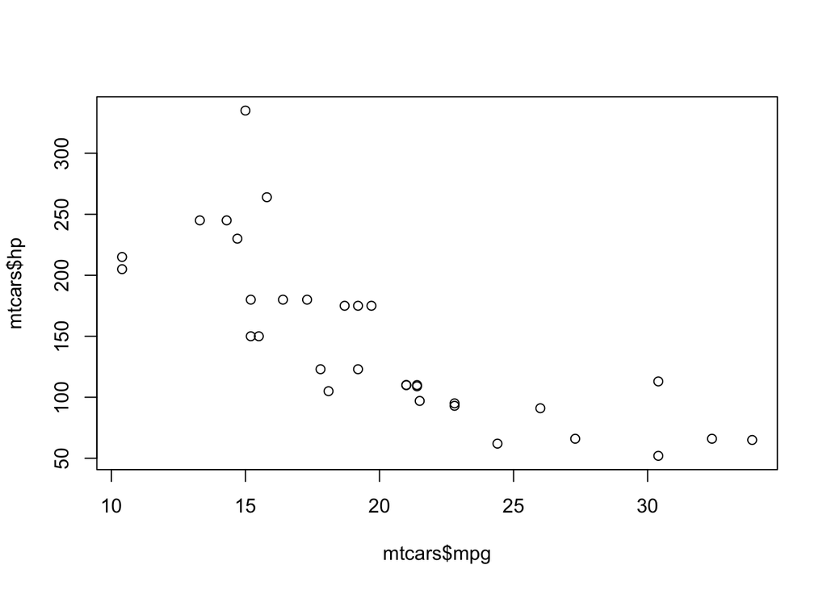

```r
# note: the following code runs equivalently
# and saves you from repeating the dollar sign column accession


# with(mtcars, plot(mpg, hp))

plot(mtcars$mpg, mtcars$hp)
```

We want easily see that there’s a negative correlation between horsepower and miles per gallon. However, if you wanted to present this data, you want to make the plot a little more descriptive. You can set the axis labels and title like so:

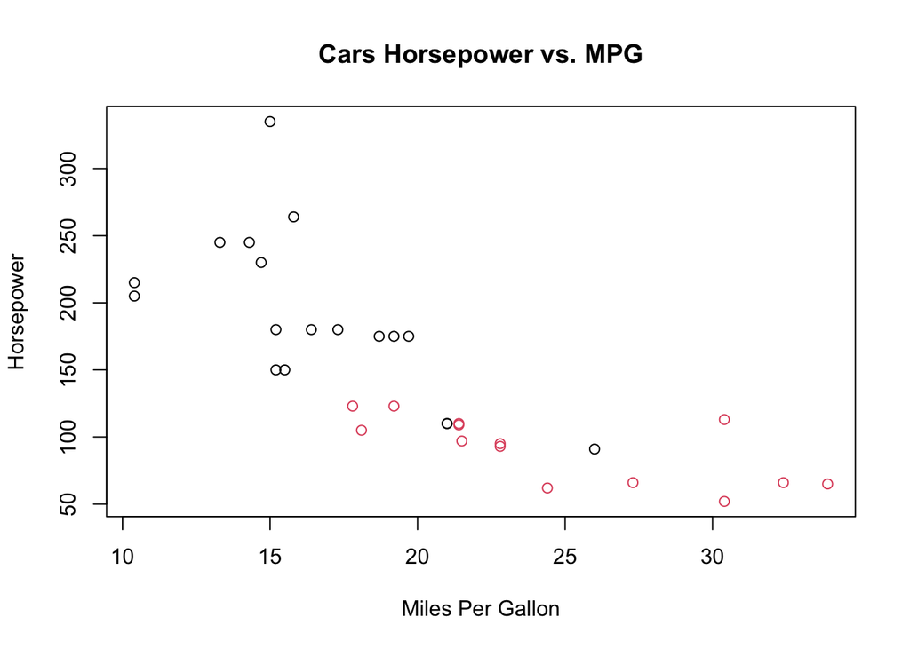

```r
plot(x = mtcars$mpg, y = mtcars$hp, col = factor(mtcars$vs), main = "Cars Horsepower vs. MPG", xlab = "Miles Per Gallon", ylab = "Horsepower")
```

Other types of plotting follow the same syntax, but there’s many many types of plots out there to visualize different types of data that. Go explore some of the ones below!

- boxplots (`boxplot()`)
- histograms (`hist()`)
- bar plots (`barplots()`)
- … and many more!

**Exercise 5.1 (Cereal Plotting)** Let’s put everything together with the cereal data set.

1. Create a new column in the original `cereal` data frame called `is_favorite`. `is_favorite` should be `"favorite"` if it was one of your favorites, and `not favorite` if it was not. (Hint: you’ve done something very similar to this a few exercises ago.)
2. Create a scatter plot of the carbohydrates on the x-axis vs. the calories on the y-axis. Make sure the axes are labeled appropriately!
3. Now, choose any two nutritional variables (calories, protein, fat, etc.), and create a scatter plot of these two variables. Color the points based on if they were your favorite or not.
4. Let’s examine the fiber content of the cereals by making a `boxplot` using the `boxplot()` command.
5. Finally, let’s save our modified cereal data. Use `write.csv()` to create a new file called `cereal_favorites.csv`!

```r
# code goes here
```

# 6 (Optional) Advanced R

I briefly mentioned the `tidyverse` package, which contains a lot of packages that are super useful for data analysis. I’ll mostly be covering the two I use the most, `ggplot2` (plotting) and `dplyr` (data manipulation). I’d recommend reading this section only after you’re comfortable with basic R syntax.

## 6.1 The `tibble` data structure

A `tibble` is just the tidyverse version of the data frame. In terms of functionality, it is basically completely interchangeable with using a regular data frame. However, I prefer tibbles since it prints the columns prettier when you look at it in the console. There’s a few other minor differences that make it less finicky than regular data frames; see the documentation for more details by running `?tibble`.

The way you make a tibble is the exact same way as you make a data frame:

```r
column1 = 1:5
column2 = c("red", "green", "blue", "black", "white")
my_tibble = tibble(numbers = column1, colors = column2)
# note: the way you make a data frame is basically the exact same syntax
# my_df = data.frame(numbers = column1, colors = column2)

my_tibble
```

| numbers | colors |
| --- | --- |
| 1 | red |
| 2 | green |
| 3 | blue |
| 4 | black |
| 5 | white |

Likewise, you can convert a data frame into a tibble using `as_tbble()`:

```r
mtcars_tibble = as_tibble(mtcars)
```

## 6.2 dplyr

The `dplyr` package implements *functional programming* – in a sense, you chain together functions *that call other functions* to process your data. The key to making this work is the *pipe operator*, `%>%`, which is implemented in `dplyr`. What this does is that it passes the output of the previous function as the first parameter into the next. As a very basic example:

```r
my_nums = 1:10

# this is the same as sum(my_nums)
my_nums %>% sum()
```

```
## [1] 55
```

The reason the pipe operator exists is that when you start nesting functions, things get very ugly. However, first, we need to look at the operations we can use. As usual, we’ll use the `mtcars` data set to demonstrate.

### 6.2.1 select

`select()` is a function that allows you to, well, select certain *columns* from a data frame. There’s a lot of options that you can read on in the documentation, but the most common way is to just list out the column names that you want to select. Note that you do *not* need to enter the names as a string. For example:

```r
print(glimpse(mtcars)) # look at the columns in mtcars
```

```
## Rows: 32
## Columns: 11
## $ mpg  <dbl> 21.0, 21.0, 22.8, 21.4, 18.7, 18.1, 14.3, 24.4, 22.8, 19.2, 17.8,…
## $ cyl  <dbl> 6, 6, 4, 6, 8, 6, 8, 4, 4, 6, 6, 8, 8, 8, 8, 8, 8, 4, 4, 4, 4, 8,…
## $ disp <dbl> 160.0, 160.0, 108.0, 258.0, 360.0, 225.0, 360.0, 146.7, 140.8, 16…
## $ hp   <dbl> 110, 110, 93, 110, 175, 105, 245, 62, 95, 123, 123, 180, 180, 180…
## $ drat <dbl> 3.90, 3.90, 3.85, 3.08, 3.15, 2.76, 3.21, 3.69, 3.92, 3.92, 3.92,…
## $ wt   <dbl> 2.620, 2.875, 2.320, 3.215, 3.440, 3.460, 3.570, 3.190, 3.150, 3.…
## $ qsec <dbl> 16.46, 17.02, 18.61, 19.44, 17.02, 20.22, 15.84, 20.00, 22.90, 18…
## $ vs   <dbl> 0, 0, 1, 1, 0, 1, 0, 1, 1, 1, 1, 0, 0, 0, 0, 0, 0, 1, 1, 1, 1, 0,…
## $ am   <dbl> 1, 1, 1, 0, 0, 0, 0, 0, 0, 0, 0, 0, 0, 0, 0, 0, 0, 1, 1, 1, 0, 0,…
## $ gear <dbl> 4, 4, 4, 3, 3, 3, 3, 4, 4, 4, 4, 3, 3, 3, 3, 3, 3, 4, 4, 4, 3, 3,…
## $ carb <dbl> 4, 4, 1, 1, 2, 1, 4, 2, 2, 4, 4, 3, 3, 3, 4, 4, 4, 1, 2, 1, 1, 2,…
##                      mpg cyl  disp  hp drat    wt  qsec vs am gear carb
## Mazda RX4           21.0   6 160.0 110 3.90 2.620 16.46  0  1    4    4
## Mazda RX4 Wag       21.0   6 160.0 110 3.90 2.875 17.02  0  1    4    4
## Datsun 710          22.8   4 108.0  93 3.85 2.320 18.61  1  1    4    1
## Hornet 4 Drive      21.4   6 258.0 110 3.08 3.215 19.44  1  0    3    1
## Hornet Sportabout   18.7   8 360.0 175 3.15 3.440 17.02  0  0    3    2
## Valiant             18.1   6 225.0 105 2.76 3.460 20.22  1  0    3    1
## Duster 360          14.3   8 360.0 245 3.21 3.570 15.84  0  0    3    4
## Merc 240D           24.4   4 146.7  62 3.69 3.190 20.00  1  0    4    2
## Merc 230            22.8   4 140.8  95 3.92 3.150 22.90  1  0    4    2
## Merc 280            19.2   6 167.6 123 3.92 3.440 18.30  1  0    4    4
## Merc 280C           17.8   6 167.6 123 3.92 3.440 18.90  1  0    4    4
## Merc 450SE          16.4   8 275.8 180 3.07 4.070 17.40  0  0    3    3
## Merc 450SL          17.3   8 275.8 180 3.07 3.730 17.60  0  0    3    3
## Merc 450SLC         15.2   8 275.8 180 3.07 3.780 18.00  0  0    3    3
## Cadillac Fleetwood  10.4   8 472.0 205 2.93 5.250 17.98  0  0    3    4
## Lincoln Continental 10.4   8 460.0 215 3.00 5.424 17.82  0  0    3    4
## Chrysler Imperial   14.7   8 440.0 230 3.23 5.345 17.42  0  0    3    4
## Fiat 128            32.4   4  78.7  66 4.08 2.200 19.47  1  1    4    1
## Honda Civic         30.4   4  75.7  52 4.93 1.615 18.52  1  1    4    2
## Toyota Corolla      33.9   4  71.1  65 4.22 1.835 19.90  1  1    4    1
## Toyota Corona       21.5   4 120.1  97 3.70 2.465 20.01  1  0    3    1
## Dodge Challenger    15.5   8 318.0 150 2.76 3.520 16.87  0  0    3    2
## AMC Javelin         15.2   8 304.0 150 3.15 3.435 17.30  0  0    3    2
## Camaro Z28          13.3   8 350.0 245 3.73 3.840 15.41  0  0    3    4
## Pontiac Firebird    19.2   8 400.0 175 3.08 3.845 17.05  0  0    3    2
## Fiat X1-9           27.3   4  79.0  66 4.08 1.935 18.90  1  1    4    1
## Porsche 914-2       26.0   4 120.3  91 4.43 2.140 16.70  0  1    5    2
## Lotus Europa        30.4   4  95.1 113 3.77 1.513 16.90  1  1    5    2
## Ford Pantera L      15.8   8 351.0 264 4.22 3.170 14.50  0  1    5    4
## Ferrari Dino        19.7   6 145.0 175 3.62 2.770 15.50  0  1    5    6
## Maserati Bora       15.0   8 301.0 335 3.54 3.570 14.60  0  1    5    8
## Volvo 142E          21.4   4 121.0 109 4.11 2.780 18.60  1  1    4    2
```

```r
# this is the most common formatting to use these functions
mtcars_subset = mtcars %>%
  select(mpg, cyl, disp, hp)

# note the columns
mtcars_subset
```

|  | mpg | cyl | disp | hp |
| --- | --- | --- | --- | --- |
| Mazda RX4 | 21.0 | 6 | 160.0 | 110 |
| Mazda RX4 Wag | 21.0 | 6 | 160.0 | 110 |
| Datsun 710 | 22.8 | 4 | 108.0 | 93 |
| Hornet 4 Drive | 21.4 | 6 | 258.0 | 110 |
| Hornet Sportabout | 18.7 | 8 | 360.0 | 175 |
| Valiant | 18.1 | 6 | 225.0 | 105 |
| Duster 360 | 14.3 | 8 | 360.0 | 245 |
| Merc 240D | 24.4 | 4 | 146.7 | 62 |
| Merc 230 | 22.8 | 4 | 140.8 | 95 |
| Merc 280 | 19.2 | 6 | 167.6 | 123 |

[output cut: 22 more lines]

I find this syntax to be a lot less annoying than the way you would handle it in base R, especially when you want to get a large number of rows. To compare:

```r
mtcars_subset = mtcars[, names(mtcars) %in% c("mpg", "cyl", "disp", "hp")]

mtcars_subset
```

|  | mpg | cyl | disp | hp |
| --- | --- | --- | --- | --- |
| Mazda RX4 | 21.0 | 6 | 160.0 | 110 |
| Mazda RX4 Wag | 21.0 | 6 | 160.0 | 110 |
| Datsun 710 | 22.8 | 4 | 108.0 | 93 |
| Hornet 4 Drive | 21.4 | 6 | 258.0 | 110 |
| Hornet Sportabout | 18.7 | 8 | 360.0 | 175 |
| Valiant | 18.1 | 6 | 225.0 | 105 |
| Duster 360 | 14.3 | 8 | 360.0 | 245 |
| Merc 240D | 24.4 | 4 | 146.7 | 62 |
| Merc 230 | 22.8 | 4 | 140.8 | 95 |
| Merc 280 | 19.2 | 6 | 167.6 | 123 |

[output cut: 22 more lines]

Additionally, there’s other ways to select columns (again, that are in the documentation), making `select()` even more powerful. This function becomes even more powerful when you combine it with other functions, as seen below.

### 6.2.2 filter

`filter()` is the row analogue to `select()`. Recall how we first showed you how to perform this by boolean indexing:

```r
# get the cars with mpg 20 and greater
mtcars_subset = mtcars[mtcars$mpg >= 20, ]

mtcars_subset
```

|  | mpg | cyl | disp | hp | drat | wt | qsec | vs | am | gear | carb |
| --- | --- | --- | --- | --- | --- | --- | --- | --- | --- | --- | --- |
| Mazda RX4 | 21.0 | 6 | 160.0 | 110 | 3.90 | 2.620 | 16.46 | 0 | 1 | 4 | 4 |
| Mazda RX4 Wag | 21.0 | 6 | 160.0 | 110 | 3.90 | 2.875 | 17.02 | 0 | 1 | 4 | 4 |
| Datsun 710 | 22.8 | 4 | 108.0 | 93 | 3.85 | 2.320 | 18.61 | 1 | 1 | 4 | 1 |
| Hornet 4 Drive | 21.4 | 6 | 258.0 | 110 | 3.08 | 3.215 | 19.44 | 1 | 0 | 3 | 1 |
| Merc 240D | 24.4 | 4 | 146.7 | 62 | 3.69 | 3.190 | 20.00 | 1 | 0 | 4 | 2 |
| Merc 230 | 22.8 | 4 | 140.8 | 95 | 3.92 | 3.150 | 22.90 | 1 | 0 | 4 | 2 |
| Fiat 128 | 32.4 | 4 | 78.7 | 66 | 4.08 | 2.200 | 19.47 | 1 | 1 | 4 | 1 |
| Honda Civic | 30.4 | 4 | 75.7 | 52 | 4.93 | 1.615 | 18.52 | 1 | 1 | 4 | 2 |
| Toyota Corolla | 33.9 | 4 | 71.1 | 65 | 4.22 | 1.835 | 19.90 | 1 | 1 | 4 | 1 |
| Toyota Corona | 21.5 | 4 | 120.1 | 97 | 3.70 | 2.465 | 20.01 | 1 | 0 | 3 | 1 |

[output cut: 4 more lines]

With `filter()`, it looks quite similar, but more readable:

```r
mtcars_subset = mtcars %>%
  filter(mpg >= 20)

mtcars_subset
```

|  | mpg | cyl | disp | hp | drat | wt | qsec | vs | am | gear | carb |
| --- | --- | --- | --- | --- | --- | --- | --- | --- | --- | --- | --- |
| Mazda RX4 | 21.0 | 6 | 160.0 | 110 | 3.90 | 2.620 | 16.46 | 0 | 1 | 4 | 4 |
| Mazda RX4 Wag | 21.0 | 6 | 160.0 | 110 | 3.90 | 2.875 | 17.02 | 0 | 1 | 4 | 4 |
| Datsun 710 | 22.8 | 4 | 108.0 | 93 | 3.85 | 2.320 | 18.61 | 1 | 1 | 4 | 1 |
| Hornet 4 Drive | 21.4 | 6 | 258.0 | 110 | 3.08 | 3.215 | 19.44 | 1 | 0 | 3 | 1 |
| Merc 240D | 24.4 | 4 | 146.7 | 62 | 3.69 | 3.190 | 20.00 | 1 | 0 | 4 | 2 |
| Merc 230 | 22.8 | 4 | 140.8 | 95 | 3.92 | 3.150 | 22.90 | 1 | 0 | 4 | 2 |
| Fiat 128 | 32.4 | 4 | 78.7 | 66 | 4.08 | 2.200 | 19.47 | 1 | 1 | 4 | 1 |
| Honda Civic | 30.4 | 4 | 75.7 | 52 | 4.93 | 1.615 | 18.52 | 1 | 1 | 4 | 2 |
| Toyota Corolla | 33.9 | 4 | 71.1 | 65 | 4.22 | 1.835 | 19.90 | 1 | 1 | 4 | 1 |
| Toyota Corona | 21.5 | 4 | 120.1 | 97 | 3.70 | 2.465 | 20.01 | 1 | 0 | 3 | 1 |

[output cut: 4 more lines]

Now, what if we want to select cars with `mpg >= 20` AND only get the rows we did before. With normal data frame operations, it starts to get messy:

```r
# you can select rows and columns separately, but that's even more typing
mtcars_subset = mtcars[mtcars$mpg >= 20,
                       names(mtcars) %in% c("mpg", "cyl", "disp", "hp")]

mtcars_subset
```

|  | mpg | cyl | disp | hp |
| --- | --- | --- | --- | --- |
| Mazda RX4 | 21.0 | 6 | 160.0 | 110 |
| Mazda RX4 Wag | 21.0 | 6 | 160.0 | 110 |
| Datsun 710 | 22.8 | 4 | 108.0 | 93 |
| Hornet 4 Drive | 21.4 | 6 | 258.0 | 110 |
| Merc 240D | 24.4 | 4 | 146.7 | 62 |
| Merc 230 | 22.8 | 4 | 140.8 | 95 |
| Fiat 128 | 32.4 | 4 | 78.7 | 66 |
| Honda Civic | 30.4 | 4 | 75.7 | 52 |
| Toyota Corolla | 33.9 | 4 | 71.1 | 65 |
| Toyota Corona | 21.5 | 4 | 120.1 | 97 |

[output cut: 4 more lines]

With the pipe and `tidyverse`, it’s much cleaner and more obvious what you’re trying to do:

```r
mtcars_subset = mtcars %>%
  select(mpg, cyl, disp, hp) %>%
  filter(mpg >= 20)

mtcars_subset
```

|  | mpg | cyl | disp | hp |
| --- | --- | --- | --- | --- |
| Mazda RX4 | 21.0 | 6 | 160.0 | 110 |
| Mazda RX4 Wag | 21.0 | 6 | 160.0 | 110 |
| Datsun 710 | 22.8 | 4 | 108.0 | 93 |
| Hornet 4 Drive | 21.4 | 6 | 258.0 | 110 |
| Merc 240D | 24.4 | 4 | 146.7 | 62 |
| Merc 230 | 22.8 | 4 | 140.8 | 95 |
| Fiat 128 | 32.4 | 4 | 78.7 | 66 |
| Honda Civic | 30.4 | 4 | 75.7 | 52 |
| Toyota Corolla | 33.9 | 4 | 71.1 | 65 |
| Toyota Corona | 21.5 | 4 | 120.1 | 97 |

[output cut: 4 more lines]

### 6.2.3 mutate

`mutate()` is a function used to either change existing columns or to create a new columns. The base R way to do is looks something as follows.

```r
# you need to explicitly make a new copy
mtcars_new = mtcars
mtcars_new$mpg_quality = ifelse(mtcars$mpg >= 20, "good", "bad")

mtcars_new
```

|  | mpg | cyl | disp | hp | drat | wt | qsec | vs | am | gear | carb | mpg_quality |
| --- | --- | --- | --- | --- | --- | --- | --- | --- | --- | --- | --- | --- |
| Mazda RX4 | 21.0 | 6 | 160.0 | 110 | 3.90 | 2.620 | 16.46 | 0 | 1 | 4 | 4 | good |
| Mazda RX4 Wag | 21.0 | 6 | 160.0 | 110 | 3.90 | 2.875 | 17.02 | 0 | 1 | 4 | 4 | good |
| Datsun 710 | 22.8 | 4 | 108.0 | 93 | 3.85 | 2.320 | 18.61 | 1 | 1 | 4 | 1 | good |
| Hornet 4 Drive | 21.4 | 6 | 258.0 | 110 | 3.08 | 3.215 | 19.44 | 1 | 0 | 3 | 1 | good |
| Hornet Sportabout | 18.7 | 8 | 360.0 | 175 | 3.15 | 3.440 | 17.02 | 0 | 0 | 3 | 2 | bad |
| Valiant | 18.1 | 6 | 225.0 | 105 | 2.76 | 3.460 | 20.22 | 1 | 0 | 3 | 1 | bad |
| Duster 360 | 14.3 | 8 | 360.0 | 245 | 3.21 | 3.570 | 15.84 | 0 | 0 | 3 | 4 | bad |
| Merc 240D | 24.4 | 4 | 146.7 | 62 | 3.69 | 3.190 | 20.00 | 1 | 0 | 4 | 2 | good |
| Merc 230 | 22.8 | 4 | 140.8 | 95 | 3.92 | 3.150 | 22.90 | 1 | 0 | 4 | 2 | good |
| Merc 280 | 19.2 | 6 | 167.6 | 123 | 3.92 | 3.440 | 18.30 | 1 | 0 | 4 | 4 | bad |

[output cut: 22 more lines]

With `mutate()`, we can simplify things a bit:

```r
mtcars_new = mtcars %>%
  mutate(mpg_quality = ifelse(mpg >= 20, "good", "bad"))

mtcars_new
```

|  | mpg | cyl | disp | hp | drat | wt | qsec | vs | am | gear | carb | mpg_quality |
| --- | --- | --- | --- | --- | --- | --- | --- | --- | --- | --- | --- | --- |
| Mazda RX4 | 21.0 | 6 | 160.0 | 110 | 3.90 | 2.620 | 16.46 | 0 | 1 | 4 | 4 | good |
| Mazda RX4 Wag | 21.0 | 6 | 160.0 | 110 | 3.90 | 2.875 | 17.02 | 0 | 1 | 4 | 4 | good |
| Datsun 710 | 22.8 | 4 | 108.0 | 93 | 3.85 | 2.320 | 18.61 | 1 | 1 | 4 | 1 | good |
| Hornet 4 Drive | 21.4 | 6 | 258.0 | 110 | 3.08 | 3.215 | 19.44 | 1 | 0 | 3 | 1 | good |
| Hornet Sportabout | 18.7 | 8 | 360.0 | 175 | 3.15 | 3.440 | 17.02 | 0 | 0 | 3 | 2 | bad |
| Valiant | 18.1 | 6 | 225.0 | 105 | 2.76 | 3.460 | 20.22 | 1 | 0 | 3 | 1 | bad |
| Duster 360 | 14.3 | 8 | 360.0 | 245 | 3.21 | 3.570 | 15.84 | 0 | 0 | 3 | 4 | bad |
| Merc 240D | 24.4 | 4 | 146.7 | 62 | 3.69 | 3.190 | 20.00 | 1 | 0 | 4 | 2 | good |
| Merc 230 | 22.8 | 4 | 140.8 | 95 | 3.92 | 3.150 | 22.90 | 1 | 0 | 4 | 2 | good |
| Merc 280 | 19.2 | 6 | 167.6 | 123 | 3.92 | 3.440 | 18.30 | 1 | 0 | 4 | 4 | bad |

[output cut: 22 more lines]

Furthermore, we can add or edit more than one column in one call:

```r
mtcars_new = mtcars %>%
  mutate(mpg_quality = ifelse(mpg >= 20, "good", "bad"), # our previous statement
         hp = scale(hp), # modify hp by standardizing to mean 0, variance 1
         hp_new = ifelse(hp >= 0, "high", "low"))  # we can use the newly create column to make another

mtcars_new
```

|  | mpg | cyl | disp | hp | drat | wt | qsec | vs | am | gear | carb | mpg_quality | hp_new |
| --- | --- | --- | --- | --- | --- | --- | --- | --- | --- | --- | --- | --- | --- |
| Mazda RX4 | 21.0 | 6 | 160.0 | -0.53509284 | 3.90 | 2.620 | 16.46 | 0 | 1 | 4 | 4 | good | low |
| Mazda RX4 Wag | 21.0 | 6 | 160.0 | -0.53509284 | 3.90 | 2.875 | 17.02 | 0 | 1 | 4 | 4 | good | low |
| Datsun 710 | 22.8 | 4 | 108.0 | -0.78304046 | 3.85 | 2.320 | 18.61 | 1 | 1 | 4 | 1 | good | low |
| Hornet 4 Drive | 21.4 | 6 | 258.0 | -0.53509284 | 3.08 | 3.215 | 19.44 | 1 | 0 | 3 | 1 | good | low |
| Hornet Sportabout | 18.7 | 8 | 360.0 | 0.41294217 | 3.15 | 3.440 | 17.02 | 0 | 0 | 3 | 2 | bad | high |
| Valiant | 18.1 | 6 | 225.0 | -0.60801861 | 2.76 | 3.460 | 20.22 | 1 | 0 | 3 | 1 | bad | low |
| Duster 360 | 14.3 | 8 | 360.0 | 1.43390296 | 3.21 | 3.570 | 15.84 | 0 | 0 | 3 | 4 | bad | high |
| Merc 240D | 24.4 | 4 | 146.7 | -1.23518023 | 3.69 | 3.190 | 20.00 | 1 | 0 | 4 | 2 | good | low |
| Merc 230 | 22.8 | 4 | 140.8 | -0.75387015 | 3.92 | 3.150 | 22.90 | 1 | 0 | 4 | 2 | good | low |
| Merc 280 | 19.2 | 6 | 167.6 | -0.34548584 | 3.92 | 3.440 | 18.30 | 1 | 0 | 4 | 4 | bad | low |

[output cut: 22 more lines]

The really useful thing is that we can put all these together in a single call, which really makes things easier to read:

```r
mtcars_subset = mtcars %>%
  select(mpg, hp) %>%
  filter(mpg >= 20) %>%
  mutate(mpg_hp_ratio = mpg/hp) %>%
  arrange(-mpg_hp_ratio) # arrange is basically order

mtcars_subset
```

|  | mpg | hp | mpg_hp_ratio |
| --- | --- | --- | --- |
| Honda Civic | 30.4 | 52 | 0.5846154 |
| Toyota Corolla | 33.9 | 65 | 0.5215385 |
| Fiat 128 | 32.4 | 66 | 0.4909091 |
| Fiat X1-9 | 27.3 | 66 | 0.4136364 |
| Merc 240D | 24.4 | 62 | 0.3935484 |
| Porsche 914-2 | 26.0 | 91 | 0.2857143 |
| Lotus Europa | 30.4 | 113 | 0.2690265 |
| Datsun 710 | 22.8 | 93 | 0.2451613 |
| Merc 230 | 22.8 | 95 | 0.2400000 |
| Toyota Corona | 21.5 | 97 | 0.2216495 |

[output cut: 4 more lines]

### 6.2.4 summarise and groupby

Finally, it’s pretty common that we want to summarize our data by a certain attribute. `group_by()` followed by `summarise()` allows us to do so. For example, to summarize mpg by the number of cylinders:

```r
mean_var_summary = mtcars %>%
  group_by(cyl) %>%
  summarise(mean = mean(mpg), variance = var(mpg)) # summarize by mean and variance

mean_var_summary
```

| cyl | mean | variance |
| --- | --- | --- |
| 4 | 26.66364 | 20.338545 |
| 6 | 19.74286 | 2.112857 |
| 8 | 15.10000 | 6.553846 |

As you can see, there’s a lot of functions that are helpful for processing your data. Feel free to either use basic R functionality or `tidyverse` in your exercises!

## 6.3 ggplot

### 6.3.1 qplot

By the way, if you’re familiar with basic R plotting, the `qplot()` function uses the same syntax, but creates prettier plots. For instance:

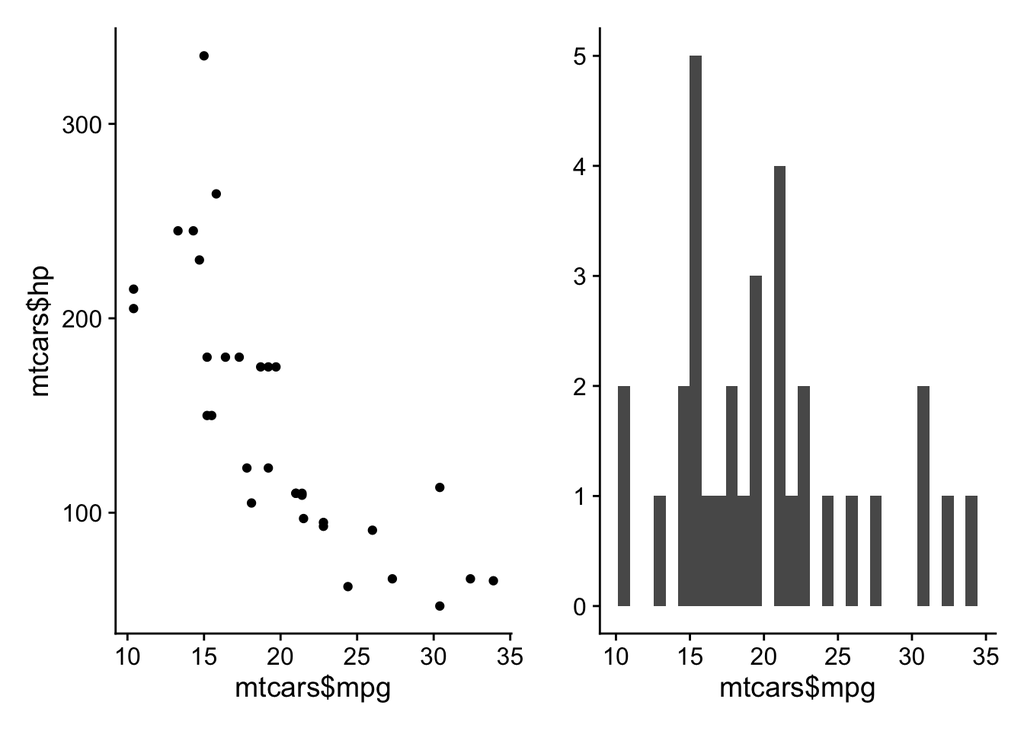

```r
library(patchwork)  # this lets you display two plots side by side with the +
p1 = qplot(mtcars$mpg, mtcars$hp)
p2 = qplot(mtcars$mpg)

p1 + p2
```

This is nice to explore variables, but it’s harder to make prettier plots.

### 6.3.2 Scatter Plots

Scatter plots tend to be the simplest and most common, so I’ll start here. We pass in the data to plot, then in `aes()` we define what to put on the axes.

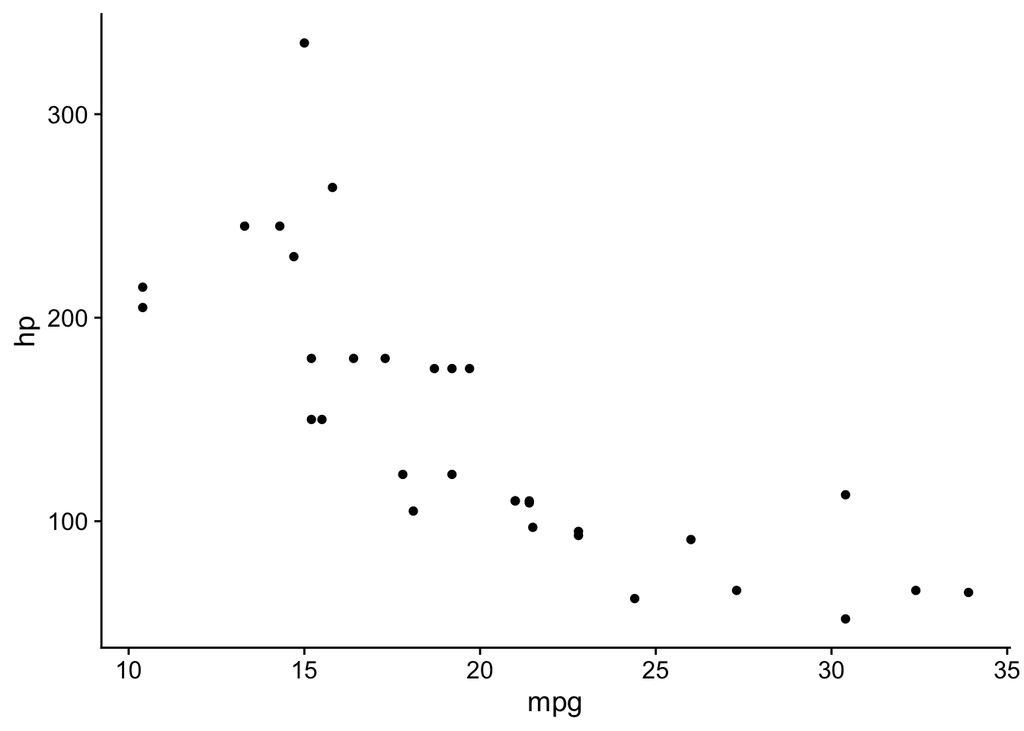

```r
p = ggplot(mtcars, aes(x = mpg, y = hp)) +
  geom_point()

p
```

We can color the points by defining the color `aes`:

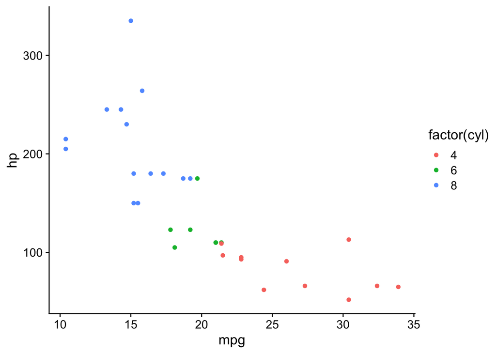

```r
# we want to make cyl a factor
# otherwise, it's a numeric value, so we get a gradient
p = ggplot(mtcars, aes(x = mpg, y = hp)) +
  geom_point(aes(color = factor(cyl)))

p
```

And we can plop a line on top with the `geom_smooth()` layer:

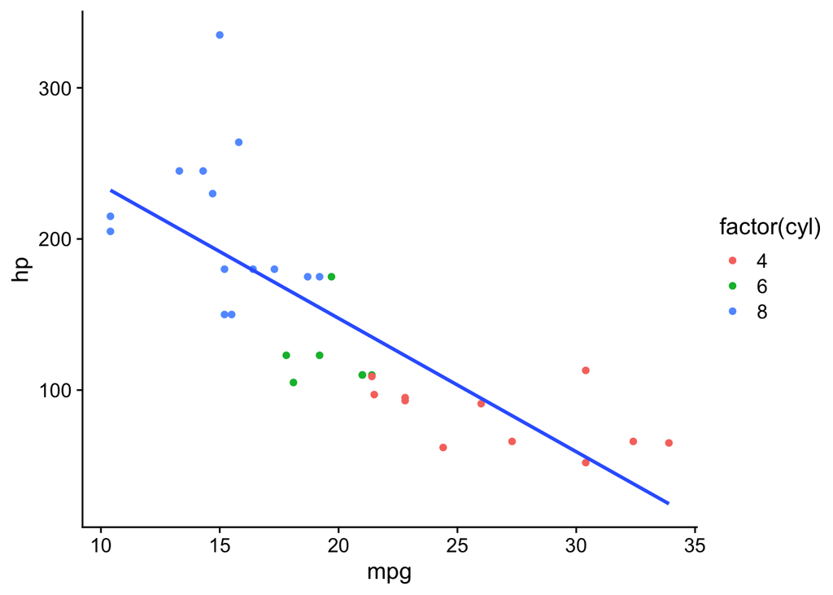

```r
# we want to make cyl a factor
# otherwise, it's a numeric value, so we get a gradient
p = ggplot(mtcars, aes(x = mpg, y = hp)) +
  geom_point(aes(color = factor(cyl))) +
  geom_smooth(se = F, method = "lm")  # hide the error margin, draw the linear regression line

p
```

Finally, we can split the data points using `facet_grid()`:

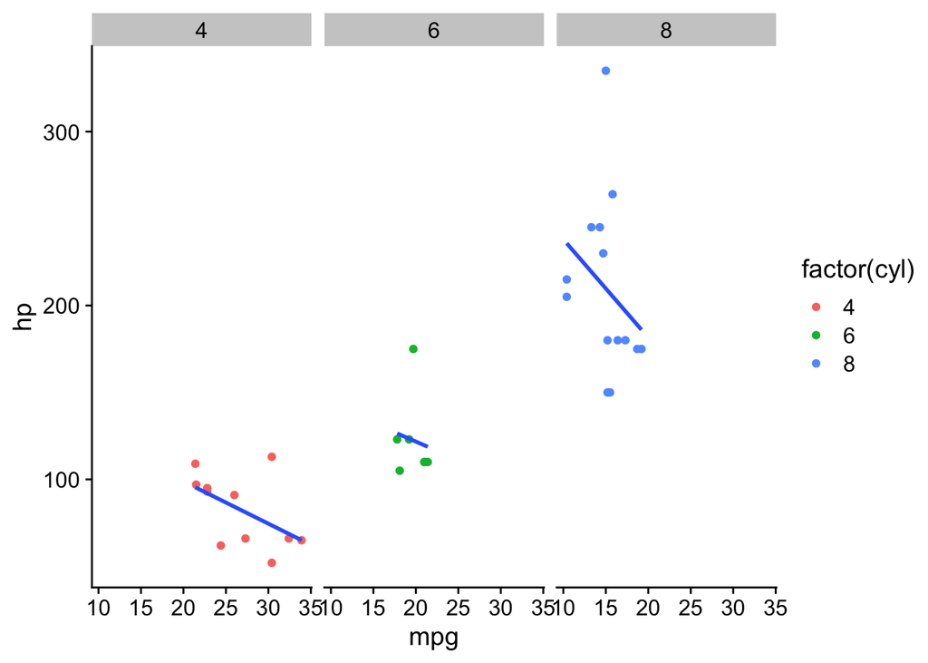

```r
# we want to make cyl a factor
# otherwise, it's a numeric value, so we get a gradient
p = ggplot(mtcars, aes(x = mpg, y = hp)) +
  geom_point(aes(color = factor(cyl))) +
  facet_grid(cols = vars(cyl)) +
  geom_smooth(se = F, method = "lm")  # hide the error margin, draw the linear regression line

p
```

There’s a whole bunch more functionality and different plot types, but I’ll leave that exploring to you.

### 6.3.3 Plotting Error Bars

Plotting error bars is important for presenting your data, though there’s no standard as to what an error bar represents. Here, we’ll just use our `mtcars` summary from last time and display the error as the standard deviation of the mean. In publications, you’ll probably most frequently see error bars representing confidence intervals or standard error of the mean. The confidence intervals are probably the most informative, though they can be a bit mathy and more difficult to calculate (it requires a lot of stats knowledge).

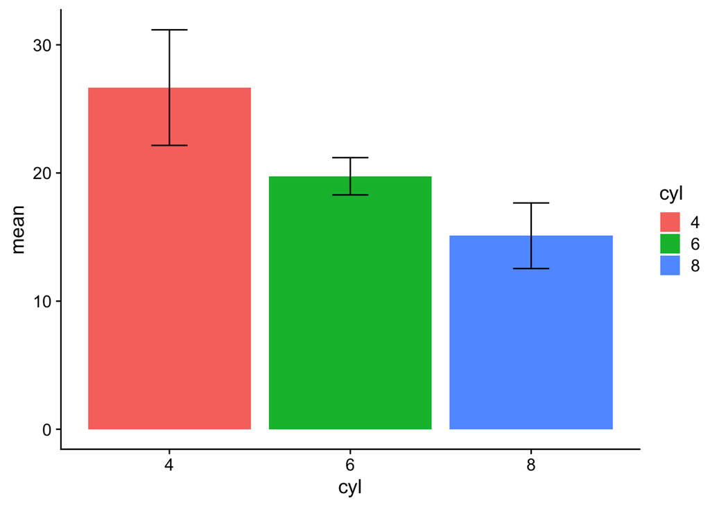

```r
# calculate the standard deviation from the variance (is sqrt(var))
plot_data = mean_var_summary %>%
  mutate(stdev = sqrt(variance),
         cyl = factor(cyl))

# create a bar plot with geom_col()
# we use fill instead of color for barplots
# we calculate the position of errors bars by +- standard deviation
ggplot(plot_data, aes(x = cyl, y = mean, fill = cyl)) +
  geom_col() +
  geom_errorbar(aes(ymin = mean - stdev, ymax = mean + stdev, width = 0.2))
```

## 6.4 Ways to write loops in `R`

`R` has alternatives to writing `for` loops; namely, there is a family of `apply` functions that, well, apply a function across a `vector`. These have the advantage of returning a `vector`, but they aren’t actually much faster than a regular loop. There’s four functions you’ll probably use:

- `apply`: this works over a matrix. It’s mostly used if you want to apply a function over rows, rather than columns (it accepts an additional argument, `MARGIN`).
- `lapply`: this returns a list (i.e. list-apply).
- `sapply`: this returns a vector or matrix, determined automatically (i.e. simple-apply). I personally prefer this one.
- `mapply`: this goes across two or more iterable objects at the same time. The syntax is slightly different, with `mapply(FUNC, X, Y, Z, ...)`, where `X`, `Y`, `Z`, are the iterable objects.

These functions use the following basic syntax (again, with the exception of `mapply`):

```
apply(X, function(x))
```

where `X` is some kind of vector/list/dataframe, and `function` is some function. The `x` passed to the function is a stand-in for the values that are being iterated over by the `apply` function. Note that you can define your own function as part of the apply function. For example, if you had a data frame and wanted to get both the mean and variance of each column and put 0s for categorical variables, you can do the following (on the `iris` data set):

```r
vals1 = sapply(iris, function(x){  # you can define your own function here!
  if (is.numeric(x)){
    return(c(mean(x), var(x)))
  } else{
    return(c(0, 0))
  }
})

vals1
```

```
##      Sepal.Length Sepal.Width Petal.Length Petal.Width Species
## [1,]    5.8433333   3.0573333     3.758000   1.1993333       0
## [2,]    0.6856935   0.1899794     3.116278   0.5810063       0
```

```r
#### for loop version:
vals2 = matrix(nrow = 2, ncol = 5, dimnames = list(NULL, names(iris)))

for(i in 1:ncol(iris)){
  x = iris[, i]
  if (is.numeric(x)){
    vals2[, i] = c(mean(x), var(x))
  } else{
    vals2[, i] = c(0, 0)
  }
}

vals2  # equivalent to vals1
```

```
##      Sepal.Length Sepal.Width Petal.Length Petal.Width Species
## [1,]    5.8433333   3.0573333     3.758000   1.1993333       0
## [2,]    0.6856935   0.1899794     3.116278   0.5810063       0
```

Syntactically, it’s considered superior in `R` to do the first version, as it’s easier to read, doesn’t involve declaring extra variables ahead of time (that matrix line looks real ugly), and overall is more flexible. Practically, you’ll probably see the for loop version more, as most people who use `R` come from another language, and the for loop syntax is more familiar (the run time isn’t much different in any case). Use whichever syntax you prefer, but it’s good to be able to understand code that other people wrote. **However, it’s still best to use an built-in function.**

That’s about it for now – the best way to learn is by practicing!